# Homework 4

Author

PSTAT 134/234

## Homework 4

**Note: If this is one of your two late homework submissions, please indicate below; also indicate whether it is your first or second late submission.**

__________________________________

This homework assignment has you practice working with some text data, doing some natural language processing. I strongly advise using Lab 7 for assistance.

You also may need to use other functions. I encourage you to make use of our textbook(s) and use the Internet to help you solve these problems. You can also work together with your classmates. If you do work together, you should provide the names of those classmates below.

Names of Collaborators (if any): William Mahnke

### Natural Language Processing

- Review: This column contains the text of user reviews, reflecting their experiences, opinions, and feedback on the Spotify app.
- Sentiment label: This column categorizes each review as either “POSITIVE” or “NEGATIVE” based on its sentiment.

The data comes from this source at Kaggle: https://www.kaggle.com/datasets/alexandrakim2201/spotify-dataset

```r
# data manipulation
library(tidyverse)
library(tidymodels)
library(reshape2)
# text mining
library(tidytext)
library(stringi)

# data visualization
library(ggplot2)
library(wordcloud)
library(kableExtra)
library(igraph)
library(ggraph)

# data modeling
library(tidymodels)
library(kernlab)
library(yardstick)

spotify <- read_csv('~/pstat-134-234/Homework/Homework 4/data/spotify-review-data.csv')
theme_set(theme_bw())  # preset the bw theme
```

#### Exercise 1

Read the data into R (or Python, whichever you prefer).

Take a look at the distribution of `label`. Are there relatively even numbers of negative and positive reviews in the data set?

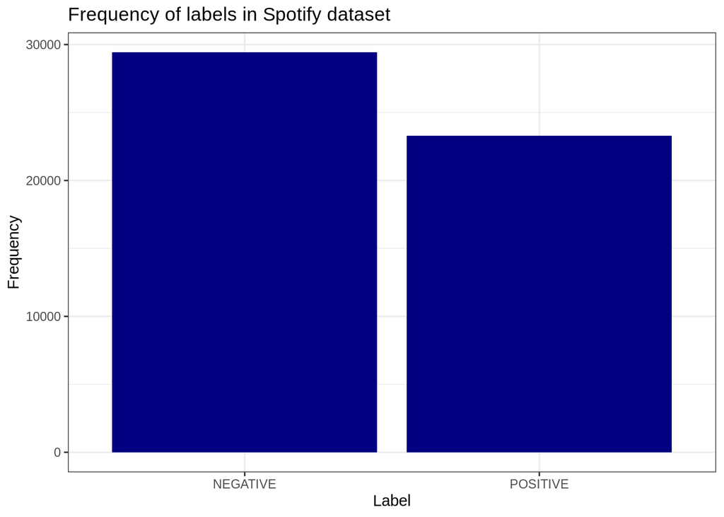

```r
ggplot(spotify) +
  geom_bar(aes(x= label), fill = "navy") +
  labs(title = "Frequency of labels in Spotify dataset",
       x = "Label",
       y = "Frequency")
```

The number of negative and positive reviews is relatively even.

#### Exercise 2

Take a random sample of $10,000$ reviews, stratified by `label`. All further exercises will be working with this smaller sample of reviews.

```r
# stratify means to ensure that the distribution of the labels column in the sample is similar to the distribution of labels in the full dataset
set.seed(13)

spotify$id <- seq.int(nrow(spotify))
spotify_split <- initial_split(spotify, prop = 10001/nrow(spotify), strata = label)
spotify_train <- training(spotify_split)
spotify_test <- testing(spotify_split)

dim(spotify_train) # 10000 reviews
```

```
[1] 10000     3
```

#### Exercise 3

Tokenize the reviews into words.

Remove stop words. (You can use any pre-made list of stop words of your choice.)

Clean the reviews. Remove punctuation and convert the letters to lowercase.

Verify that this process worked correctly.

```r
spotify_train$Review <- spotify_train$Review %>%
  iconv(from = 'UTF-8', to = 'ASCII//TRANSLIT') %>% # convert accented characters into ASCI equivalent
  stri_replace_all_regex("[^\\p{L}\\p{N}\\s]", "") %>%  # remove everything except letter, number, whitespace
  tolower()
```

```r
# data("stop_words") is SMART stopwords
spotify_train_words <- spotify_train %>%
  unnest_tokens(word, Review)  %>% # tokenize reviews into words
  anti_join(stop_words) # remove stop words
spotify_train_words %>%
  count(word, sort = T) %>%
  head(n = 30) %>%
  kbl()
```

| word | n |
| --- | --- |
| app | 5180 |
| music | 3730 |
| songs | 2641 |
| spotify | 2639 |
| song | 2119 |
| play | 1677 |
| love | 1399 |
| premium | 1321 |
| listen | 1312 |
| ads | 1113 |
| playlist | 1050 |
| playing | 997 |
| dont | 990 |
| im | 929 |
| update | 835 |
| fix | 683 |
| time | 683 |
| doesnt | 584 |
| phone | 583 |
| listening | 573 |
| ive | 556 |
| podcasts | 478 |
| NA | 472 |
| stop | 456 |
| free | 446 |
| playlists | 432 |
| annoying | 409 |
| wont | 380 |
| easy | 373 |
| pay | 368 |

#### Exercise 4

Create a bar chart of the most commonly-occurring words (not including stop words).

Create bar charts of the most commonly-occurring words, broken down by `label`. What words are more common in positive reviews? What words are more common in negative reviews?

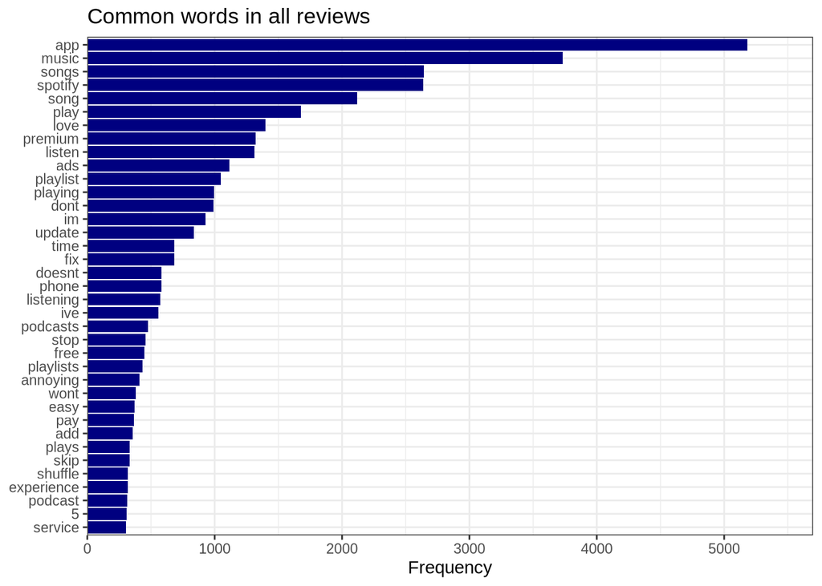

```r
spotify_train_words %>%
  filter(!is.na(word)) %>%
  count(word, sort = TRUE) %>%
  filter(n > 300) %>%
  mutate(word = reorder(word, n)) %>%
  ggplot(aes(n, word)) +
  geom_col(fill = "navy") +
  scale_x_continuous(expand = expansion(mult = c(0, .1))) +
  labs(title = "Common words in all reviews", x = "Frequency", y = NULL)
```

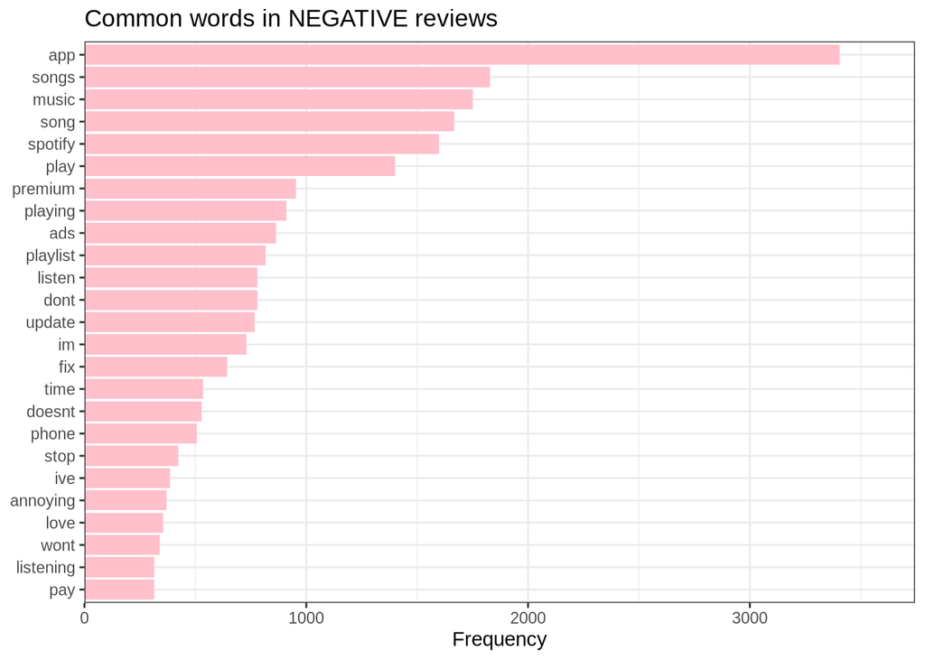

```r
spotify_train_words %>%
  filter(label == 'NEGATIVE') %>%
  count(word, sort = TRUE) %>%
  filter(n > 300) %>%
  mutate(word = reorder(word, n)) %>%
  ggplot(aes(n, word)) +
  geom_col(fill = "pink") +
  scale_x_continuous(expand = expansion(mult = c(0, .1))) +
  labs(title = "Common words in NEGATIVE reviews", x = "Frequency", y = NULL)
```

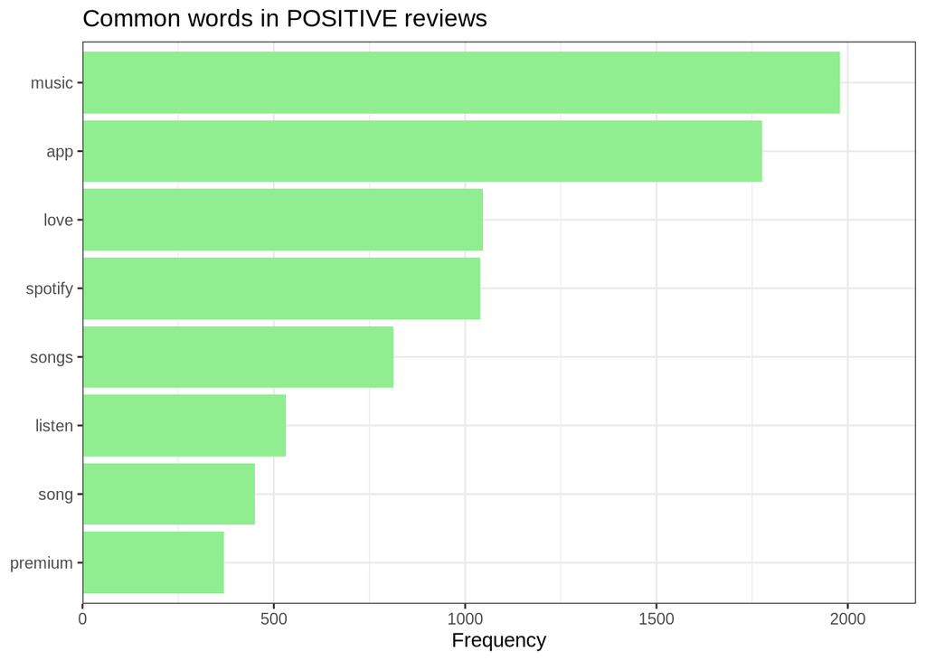

```r
spotify_train_words %>%
  filter(label == 'POSITIVE') %>%
  filter(!is.na(word)) %>%
  count(word, sort = TRUE) %>%
  filter(n > 300) %>%
  mutate(word = reorder(word, n)) %>%
  ggplot(aes(n, word)) +
  geom_col(fill = "lightgreen") +
  scale_x_continuous(expand = expansion(mult = c(0, .1))) +
  labs(title = "Common words in POSITIVE reviews", x = "Frequency", y = NULL)
```

Some of the most frequent words in all reviews are: “app”, “songs”, “music”, “spotify,” and “play”. These words are used in both positive and negative reviews. The words more specific to negative reviews are: “playlist”, “ads”, “update”, “fix”, time”, and “annoying”. A word specific to positive reviews is “love”. “There are more words used in negative reviews that have a frequency of over 300.

#### Exercise 5

Create a word cloud of the most commonly-occurring words overall, broken down by “positive” or “negative” sentiment (using the Bing sentiment lexicon).

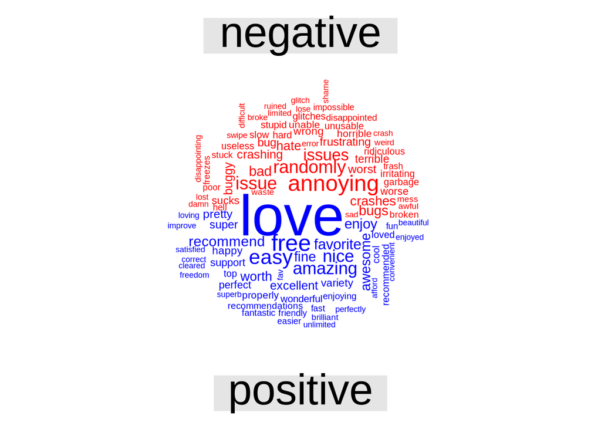

```r
spotify_train_words %>%
  inner_join(get_sentiments("bing")) %>%
  count(word, sentiment, sort = TRUE) %>%
  acast(word ~ sentiment, value.var = "n", fill = 0) %>%
  comparison.cloud(colors = c("red", "blue"),
                   max.words = 100)
```

#### Exercise 6

Calculate the tf-idf values for the words in the dataset.

Find the 30 words with the largest tf-idf values.

Find the 30 words with the smallest tf-idf values.

```r
spotify_train_tf_idf <- spotify_train_words %>%
  count(id, word) %>%
  bind_tf_idf(term = word,
              document = id,
              n = n)

# 30 largest tf-idf values
spotify_train_tf_idf %>%
  arrange(desc(tf_idf)) %>%
  head(n = 30) %>%
  kbl() %>%
  scroll_box(width = "400px", height = "500px")
```

| id | word | n | tf | idf | tf_idf |
| --- | --- | --- | --- | --- | --- |
| 47425 | advertisemens | 1 | 1 | 9.200290 | 9.200290 |
| 49137 | topical | 1 | 1 | 9.200290 | 9.200290 |
| 49152 | unprecedented | 1 | 1 | 9.200290 | 9.200290 |
| 49309 | ilkee | 1 | 1 | 9.200290 | 9.200290 |
| 49377 | neverminds | 1 | 1 | 9.200290 | 9.200290 |
| 49450 | likeeeit | 1 | 1 | 9.200290 | 9.200290 |
| 49622 | 2023 | 1 | 1 | 9.200290 | 9.200290 |
| 49720 | mzemer | 1 | 1 | 9.200290 | 9.200290 |
| 50179 | goooddd | 1 | 1 | 9.200290 | 9.200290 |
| 50262 | lovee | 1 | 1 | 9.200290 | 9.200290 |
| 50264 | sexy | 1 | 1 | 9.200290 | 9.200290 |
| 50314 | manigandn | 1 | 1 | 9.200290 | 9.200290 |
| 50676 | superpower | 1 | 1 | 9.200290 | 9.200290 |
| 50792 | temaa | 1 | 1 | 9.200290 | 9.200290 |
| 50830 | loveitt | 1 | 1 | 9.200290 | 9.200290 |
| 51008 | exelent | 1 | 1 | 9.200290 | 9.200290 |
| 51197 | goool | 1 | 1 | 9.200290 | 9.200290 |
| 51525 | muslim | 1 | 1 | 9.200290 | 9.200290 |
| 51860 | peermohamd | 2 | 1 | 9.200290 | 9.200290 |
| 51902 | momment | 1 | 1 | 9.200290 | 9.200290 |
| 52025 | ape | 1 | 1 | 9.200290 | 9.200290 |
| 52409 | ankushpal | 1 | 1 | 9.200290 | 9.200290 |
| 52503 | excelente | 1 | 1 | 9.200290 | 9.200290 |
| 49448 | goood | 1 | 1 | 8.507143 | 8.507143 |
| 49677 | sensational | 1 | 1 | 8.507143 | 8.507143 |
| 49812 | amaze | 1 | 1 | 8.507143 | 8.507143 |
| 50191 | likeee | 1 | 1 | 8.507143 | 8.507143 |
| 50237 | likeee | 1 | 1 | 8.507143 | 8.507143 |
| 50798 | marvelous | 1 | 1 | 8.507143 | 8.507143 |
| 50988 | satisfy | 1 | 1 | 8.507143 | 8.507143 |

```r
# 30 smallest tf-idf values
spotify_train_tf_idf %>%
  arrange(tf_idf) %>%
  head(n = 30) %>%
  kbl() %>%
  scroll_box(width = "400px", height = "500px")
```

| id | word | n | tf | idf | tf_idf |
| --- | --- | --- | --- | --- | --- |
| 12625 | app | 1 | 0.0181818 | 0.9313018 | 0.0169328 |
| 14808 | app | 1 | 0.0222222 | 0.9313018 | 0.0206956 |
| 38943 | app | 1 | 0.0232558 | 0.9313018 | 0.0216582 |
| 10814 | app | 1 | 0.0238095 | 0.9313018 | 0.0221739 |
| 4566 | app | 1 | 0.0243902 | 0.9313018 | 0.0227147 |
| 9951 | app | 1 | 0.0243902 | 0.9313018 | 0.0227147 |
| 27395 | app | 1 | 0.0243902 | 0.9313018 | 0.0227147 |
| 31460 | app | 1 | 0.0243902 | 0.9313018 | 0.0227147 |
| 31936 | app | 1 | 0.0243902 | 0.9313018 | 0.0227147 |
| 39921 | app | 1 | 0.0243902 | 0.9313018 | 0.0227147 |
| 45589 | app | 1 | 0.0243902 | 0.9313018 | 0.0227147 |
| 12070 | app | 1 | 0.0250000 | 0.9313018 | 0.0232825 |
| 28506 | app | 1 | 0.0250000 | 0.9313018 | 0.0232825 |
| 34036 | app | 1 | 0.0250000 | 0.9313018 | 0.0232825 |
| 37032 | app | 1 | 0.0250000 | 0.9313018 | 0.0232825 |
| 38787 | app | 1 | 0.0250000 | 0.9313018 | 0.0232825 |
| 47525 | app | 1 | 0.0250000 | 0.9313018 | 0.0232825 |
| 19880 | app | 1 | 0.0256410 | 0.9313018 | 0.0238795 |
| 20446 | app | 1 | 0.0256410 | 0.9313018 | 0.0238795 |
| 40031 | app | 1 | 0.0256410 | 0.9313018 | 0.0238795 |
| 43523 | app | 1 | 0.0256410 | 0.9313018 | 0.0238795 |
| 46987 | app | 1 | 0.0256410 | 0.9313018 | 0.0238795 |
| 894 | app | 1 | 0.0263158 | 0.9313018 | 0.0245079 |
| 10801 | app | 1 | 0.0263158 | 0.9313018 | 0.0245079 |
| 19366 | app | 1 | 0.0263158 | 0.9313018 | 0.0245079 |
| 26026 | app | 1 | 0.0263158 | 0.9313018 | 0.0245079 |
| 27473 | app | 1 | 0.0263158 | 0.9313018 | 0.0245079 |
| 39309 | app | 1 | 0.0263158 | 0.9313018 | 0.0245079 |
| 39590 | app | 1 | 0.0263158 | 0.9313018 | 0.0245079 |
| 5294 | app | 1 | 0.0270270 | 0.9313018 | 0.0251703 |

#### Exercise 7

Find the 30 most commonly occuring bigrams.

Create graphs visualizing the networks of bigrams, broken down by `label`. That is, make one graph of the network of bigrams for the positive reviews, and one graph of the network for the negative reviews.

What patterns do you notice?

```r
spotify_train_bigrams <- spotify_train %>%
  unnest_tokens(bigram, Review, token = 'ngrams', n =2) %>% # create bigrams (pairs of words)
  separate(bigram, c("word1", "word2"), sep = " ") %>% # split bigram into sep words
  filter(!word1 %in% stop_words$word) %>% # filter for stop words
  filter(!word2 %in% stop_words$word) %>%
  unite(bigram, word1, word2, sep = " ") # combine words into bigram

spotify_train_bigrams %>%
  count(bigram, sort = TRUE) %>%
  slice(-1) %>%
  head(n = 30) %>%
  kbl() %>%
  scroll_box(width = "400px", height = "500px")
```

| bigram | n |
| --- | --- |
| music app | 351 |
| love spotify | 217 |
| spotify premium | 103 |
| 5 stars | 101 |
| play music | 100 |
| internet connection | 96 |
| random songs | 89 |
| music streaming | 87 |
| stops playing | 87 |
| stop playing | 75 |
| recent update | 74 |
| playing music | 73 |
| nice app | 72 |
| play bar | 67 |
| free version | 66 |
| buy premium | 64 |
| 30 minutes | 62 |
| sound quality | 62 |
| im listening | 60 |
| joe rogan | 60 |
| wont play | 57 |
| amazing app | 56 |
| youtube music | 56 |
| 5 star | 55 |
| favorite music | 54 |
| 2 songs | 53 |
| favorite songs | 49 |
| play songs | 49 |
| premium user | 48 |
| starts playing | 48 |

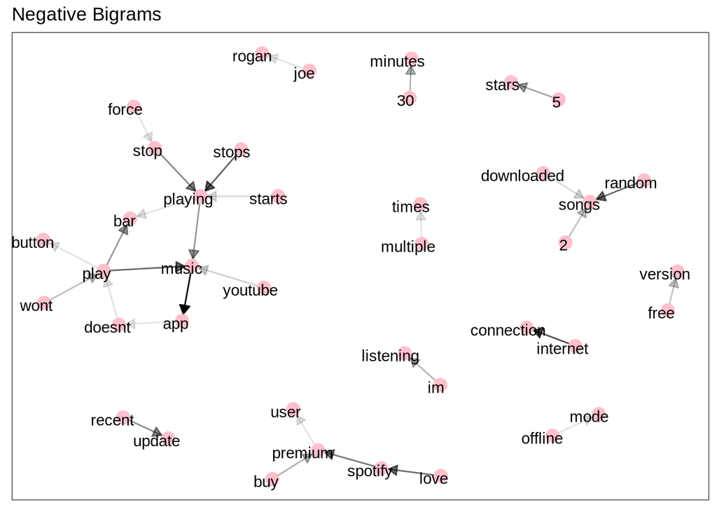

```r
bigram_graph_neg <- spotify_train_bigrams %>%
  filter(label == "NEGATIVE") %>%
  separate(bigram, c("word1", "word2"), sep = " ") %>%
  count(word1, word2) %>%
  arrange(desc(n)) %>%
  slice(-1) %>%
  slice_head(n = 30) %>%
 # mutate(n = as.integer(n)) %>%
  graph_from_data_frame()

bigram_graph_pos <- spotify_train_bigrams %>%
  filter(label == "POSITIVE") %>%
  separate(bigram, c("word1", "word2"), sep = " ") %>%
  count(word1, word2) %>%
  arrange(desc(n)) %>%
  slice(-1) %>%
  slice_head(n = 30) %>%
 # mutate(n = as.integer(n)) %>%
  graph_from_data_frame()

a <- grid::arrow(type = "closed", length = unit(.095, "inches"))

ggraph(bigram_graph_neg, layout = "fr") +
  geom_edge_link(aes(edge_alpha = n), show.legend = FALSE,
                 arrow = a, end_cap = circle(.07, 'inches')) +
  geom_node_point(color = "pink", size = 4) +
  geom_node_text(aes(label = name), vjust = 0.75, hjust = 0.75) +
  ggtitle(label = "Negative Bigrams")
```

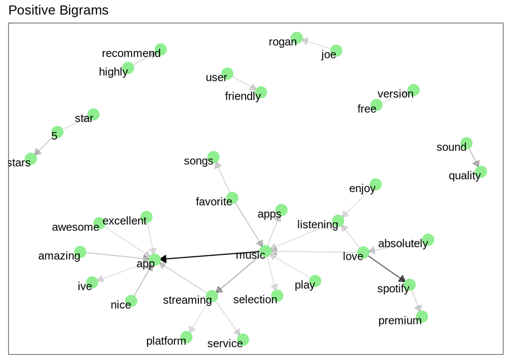

```r
ggraph(bigram_graph_pos, layout = "fr") +
  geom_edge_link(aes(edge_alpha = n), show.legend = FALSE,
                 arrow = a, end_cap = circle(.07, 'inches')) +
  geom_node_point(color = "lightgreen", size = 5) +
  geom_node_text(aes(label = name), vjust = 1, hjust = 1) +
  ggtitle(label = "Positive Bigrams")
```

#### Exercise 8

Using the tokenized **words** and their corresponding tf-idf scores, fit a **linear support vector machine** to predict whether a given review is positive or negative.

- Split the data using stratified sampling, with 70% training and 30% testing;
- Drop any columns with zero variance;
- Fit a linear support vector machine using default values for any hyperparameters;
- Calculate the model **accuracy** on your testing data.

```r
spotify_tokens <- spotify_train_tf_idf %>%
  rename(review_label = label,
         review_id = id) %>%
  group_by(review_id, review_label, word) %>%
  summarise(tf_idf = sum(tf_idf), .groups = 'drop') %>%
  pivot_wider(names_from = word,
              values_from = tf_idf,
              values_fill = 0) %>%
  mutate(review_label = factor(review_label)) %>%
  select(-review_id)

spotify_tokens_split <- initial_split(spotify_tokens, prop = 0.7)
spotify_tokens_train <- training(spotify_tokens_split)
spotify_tokens_test <- testing(spotify_tokens_split)

# recipe
spotify_recipe <- recipe(review_label ~ ., data = spotify_tokens_train) %>%
  step_zv(all_predictors())

prep(spotify_recipe) %>%
  bake(spotify_tokens_train) %>%
  select(review_label, everything()) %>%
  summary()

svmlin <- svm_linear(mode = "classification", cost = 1, margin = 0.1) %>%
  set_engine("kernlab")

svmlin_wkflow <- workflow() %>%
  add_model(svmlin) %>%
  add_recipe(spotify_recipe)

svmlin_fit <- svmlin_wkflow %>%
  fit(data = spotify_tokens_train)

svmlin_pred <- predict(svmlin_fit, new_data = spotify_tokens_test)

# to avoid fitting the model again on the training data, i saved the model as R object to load for convenience
save(svmlin_fit, file = "~/pstat-134-234/Homework/Homework 4/svmlin_fit.RData")
save(spotify_tokens_train, file = "~/pstat-134-234/Homework/Homework 4/spotify_tokens_train.RData")
save(spotify_tokens_test, file = "~/pstat-134-234/Homework/Homework 4/spotify_tokens_test.RData")
save(svmlin_fit, file = "~/pstat-134-234/Homework/Homework 4/svmlin_fit.RData")
save(svmlin_pred, file = "~/pstat-134-234/Homework/Homework 4/svmlin_pred.RData")
```

```r
load('~/pstat-134-234/Homework/Homework 4/spotify_tokens_test.RData')
load('~/pstat-134-234/Homework/Homework 4/spotify_tokens_train.RData')

# svmlin_pred <- predict(svmlin_fit, new_data = spotify_tokens_test)
load('~/pstat-134-234/Homework/Homework 4/svmlin_pred.RData')

svmlin_results <- bind_cols(spotify_tokens_test %>% select(review_label),
                            svmlin_pred)

# model accuracy of 73.44%
accuracy(svmlin_results, truth = review_label, estimate = .pred_class)
```

```
# A tibble: 1 × 3
  .metric  .estimator .estimate
  <chr>    <chr>          <dbl>
1 accuracy binary         0.734
```

The model is 73.44% accurate when predicting reviews on the testing set.

#### For 234 Students

#### Exercise 9

Using **either** Bag of Words or Word2Vec, extract a matrix of features. (Note: You can reduce the size of the dataset even further by working with a sample of $3,000$ reviews if need be.)

#### Exercise 10

Fit and tune a **logistic regression model, using lasso regularization**. Follow the same procedure as before, with a few changes:

- Stratified sampling, with a 70/30 split;
- Drop any columns with zero variance;
- Tune `penalty`, using the default values;
- Calculate your best model’s **accuracy** on the testing data.